# Satellite Image Analysis

## Basic Satellite Image Analysis

### In this notebook, we will analyze satellite image of an agricultural land and find its altitude and slope

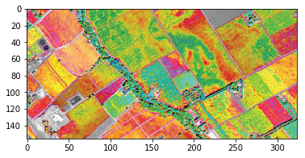

```
(156, 324, 3)
```

The shape of the ndarray show that it is a three layered matrix. The first two numbers here are length and width, and the third number (i.e. 3) is for three layers: Red, Green and Blue.

RGB color mapping

- RED pixel indicates Altitude
- GREEN pixel indicates Slope
- BLUE pixel indicates Aspect (An aspect is the compass direction that a slope faces)

The higher values denote higher altitude, aspect and slope.

Let us apply red mask and highlight all the high altitude areas. We will do this by detecting high intensity RED Pixels and muting down other areas.

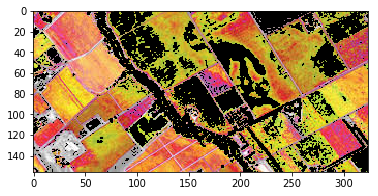

Looks like this land is on high altitude. Let us apply green mask and highlight all the high slope areas.

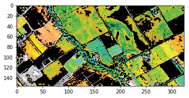

[figure not shown]

In this notebook, we have learnt how to split a sattelute image and find altitude, slope, aspect.